# Project: Investigate a Dataset - TMDb movie data

- Introduction
- Data Wrangling
- Exploratory Data Analysis
- Conclusions

## Introduction

> This dataset contains more than 10,000 records of movies including their budget, revenue, cast, directors, genres, release year etc. Even though many different analysis can be made with this data, I personally chose to go into detail regarding the different genres and their popularity through the years and the 1 or 2 factors that affect the popularity of the movie.

Import the required packages for your analysis.

```python
#import the required packages
import pandas as pd
import numpy as np
import matplotlib
import matplotlib.pyplot as plt
import seaborn as sns
% matplotlib inline
```

## Data Wrangling

Here we will load the data, check for cleanliness, and then trim and clean the dataset for analysis.

### General Properties

To check whether the file(tmdb-movies.csv) has been correctly loaded into the Jupyter notebook and to print out a few lines to inspect the data.

```python
#to read the tmdb-movies.csv file (the original dataset)
df_movies = pd.read_csv('tmdb-movies.csv')
```

```python
#to display few rows of data of tmdb-movies.csv file
df_movies.head()
```

|  | id | imdb_id | popularity | budget | revenue | original_title | cast | homepage | director | tagline | ... | overview | runtime | genres | production_companies | release_date | vote_count | vote_average | release_year | budget_adj | revenue_adj |
| --- | --- | --- | --- | --- | --- | --- | --- | --- | --- | --- | --- | --- | --- | --- | --- | --- | --- | --- | --- | --- | --- |
| 0 | 135397 | tt0369610 | 32.985763 | 150000000 | 1513528810 | Jurassic World | Chris Pratt\|Bryce Dallas Howard\|Irrfan Khan\|Vi... | http://www.jurassicworld.com/ | Colin Trevorrow | The park is open. | ... | Twenty-two years after the events of Jurassic ... | 124 | Action\|Adventure\|Science Fiction\|Thriller | Universal Studios\|Amblin Entertainment\|Legenda... | 6/9/15 | 5562 | 6.5 | 2015 | 1.379999e+08 | 1.392446e+09 |
| 1 | 76341 | tt1392190 | 28.419936 | 150000000 | 378436354 | Mad Max: Fury Road | Tom Hardy\|Charlize Theron\|Hugh Keays-Byrne\|Nic... | http://www.madmaxmovie.com/ | George Miller | What a Lovely Day. | ... | An apocalyptic story set in the furthest reach... | 120 | Action\|Adventure\|Science Fiction\|Thriller | Village Roadshow Pictures\|Kennedy Miller Produ... | 5/13/15 | 6185 | 7.1 | 2015 | 1.379999e+08 | 3.481613e+08 |
| 2 | 262500 | tt2908446 | 13.112507 | 110000000 | 295238201 | Insurgent | Shailene Woodley\|Theo James\|Kate Winslet\|Ansel... | http://www.thedivergentseries.movie/#insurgent | Robert Schwentke | One Choice Can Destroy You | ... | Beatrice Prior must confront her inner demons ... | 119 | Adventure\|Science Fiction\|Thriller | Summit Entertainment\|Mandeville Films\|Red Wago... | 3/18/15 | 2480 | 6.3 | 2015 | 1.012000e+08 | 2.716190e+08 |
| 3 | 140607 | tt2488496 | 11.173104 | 200000000 | 2068178225 | Star Wars: The Force Awakens | Harrison Ford\|Mark Hamill\|Carrie Fisher\|Adam D... | http://www.starwars.com/films/star-wars-episod... | J.J. Abrams | Every generation has a story. | ... | Thirty years after defeating the Galactic Empi... | 136 | Action\|Adventure\|Science Fiction\|Fantasy | Lucasfilm\|Truenorth Productions\|Bad Robot | 12/15/15 | 5292 | 7.5 | 2015 | 1.839999e+08 | 1.902723e+09 |
| 4 | 168259 | tt2820852 | 9.335014 | 190000000 | 1506249360 | Furious 7 | Vin Diesel\|Paul Walker\|Jason Statham\|Michelle ... | http://www.furious7.com/ | James Wan | Vengeance Hits Home | ... | Deckard Shaw seeks revenge against Dominic Tor... | 137 | Action\|Crime\|Thriller | Universal Pictures\|Original Film\|Media Rights ... | 4/1/15 | 2947 | 7.3 | 2015 | 1.747999e+08 | 1.385749e+09 |

5 rows × 21 columns

```python
#to get how many rows and columns of data are present in tmdb-movies.csv file
df_movies.shape
```

```
(10866, 21)
```

```python
#to get the data types and names of columns of tmdb-movies.csv file.
df_movies.info()
```

```
<class 'pandas.core.frame.DataFrame'>
RangeIndex: 10866 entries, 0 to 10865
Data columns (total 21 columns):
id                      10866 non-null int64
imdb_id                 10856 non-null object
popularity              10866 non-null float64
budget                  10866 non-null int64
revenue                 10866 non-null int64
original_title          10866 non-null object
cast                    10790 non-null object
homepage                2936 non-null object
director                10822 non-null object
tagline                 8042 non-null object
keywords                9373 non-null object
overview                10862 non-null object
runtime                 10866 non-null int64
genres                  10843 non-null object
production_companies    9836 non-null object
release_date            10866 non-null object
vote_count              10866 non-null int64
vote_average            10866 non-null float64
release_year            10866 non-null int64
budget_adj              10866 non-null float64
revenue_adj             10866 non-null float64
dtypes: float64(4), int64(6), object(11)
memory usage: 1.7+ MB
```

### Data Cleaning

From the above detailed description of columns and data of the TMDB dataset we can see that there are a lot of unwanted columns with respect to our analysis, difference in the data count in different columns and we also have to check whether the correct data type has been given to the columns we are considering for our analysis.

This can be done by data cleaning.

1. First we have to drop out the uneccessary columns for our analysis.
2. Secondly we have to check for NULL values or missing values and either update them with the mean value of the columns or else remove these data.
3. Thirdly we have to ensure that there no duplicates in the dataset.
4. Fourthly check whether the proper data types are assigned to the columns required for our analysis.
5. Lastly we have to create another data frame to get only the required columns for our analysis.(This depends on our analysis).

```python
#to drop out uneccessary columns
df_movies.drop(['imdb_id', 'homepage', 'tagline', 'keywords', 'overview', 'production_companies',
                'release_date','vote_count', 'budget_adj','revenue_adj'], axis=1, inplace=True)
```

```python
#to check whether the changes have been implemented.
df_movies.head()
```

|  | id | popularity | budget | revenue | original_title | cast | director | runtime | genres | vote_average | release_year |
| --- | --- | --- | --- | --- | --- | --- | --- | --- | --- | --- | --- |
| 0 | 135397 | 32.985763 | 150000000 | 1513528810 | Jurassic World | Chris Pratt\|Bryce Dallas Howard\|Irrfan Khan\|Vi... | Colin Trevorrow | 124 | Action\|Adventure\|Science Fiction\|Thriller | 6.5 | 2015 |
| 1 | 76341 | 28.419936 | 150000000 | 378436354 | Mad Max: Fury Road | Tom Hardy\|Charlize Theron\|Hugh Keays-Byrne\|Nic... | George Miller | 120 | Action\|Adventure\|Science Fiction\|Thriller | 7.1 | 2015 |
| 2 | 262500 | 13.112507 | 110000000 | 295238201 | Insurgent | Shailene Woodley\|Theo James\|Kate Winslet\|Ansel... | Robert Schwentke | 119 | Adventure\|Science Fiction\|Thriller | 6.3 | 2015 |
| 3 | 140607 | 11.173104 | 200000000 | 2068178225 | Star Wars: The Force Awakens | Harrison Ford\|Mark Hamill\|Carrie Fisher\|Adam D... | J.J. Abrams | 136 | Action\|Adventure\|Science Fiction\|Fantasy | 7.5 | 2015 |
| 4 | 168259 | 9.335014 | 190000000 | 1506249360 | Furious 7 | Vin Diesel\|Paul Walker\|Jason Statham\|Michelle ... | James Wan | 137 | Action\|Crime\|Thriller | 7.3 | 2015 |

```python
df_movies.info()
```

```
<class 'pandas.core.frame.DataFrame'>
RangeIndex: 10866 entries, 0 to 10865
Data columns (total 11 columns):
id                10866 non-null int64
popularity        10866 non-null float64
budget            10866 non-null int64
revenue           10866 non-null int64
original_title    10866 non-null object
cast              10790 non-null object
director          10822 non-null object
runtime           10866 non-null int64
genres            10843 non-null object
vote_average      10866 non-null float64
release_year      10866 non-null int64
dtypes: float64(2), int64(5), object(4)
memory usage: 933.9+ KB
```

```python
#to check for the NULL values count in each column
df_movies.isnull().sum()
```

```
id                 0
popularity         0
budget             0
revenue            0
original_title     0
cast              76
director          44
runtime            0
genres            23
vote_average       0
release_year       0
dtype: int64
```

```python
#since the missing values are all of non numeric type the most we can do to  eliminate null values is to drop all NULL values in
#the dataset
df_movies.dropna(inplace=True)
```

```python
df_movies.isnull().sum()
```

```
id                0
popularity        0
budget            0
revenue           0
original_title    0
cast              0
director          0
runtime           0
genres            0
vote_average      0
release_year      0
dtype: int64
```

```python
#now we check for the number of duplicate values
sum(df_movies.duplicated())
```

```
1
```

```python
#to drop the duplicate values
df_movies.drop_duplicates(inplace=True)
```

```python
#to check whether the duplicate values have been dropped
sum(df_movies.duplicated())
```

```
0
```

```python
#to check the data types of all the columns
df_movies.dtypes
```

```
id                  int64
popularity        float64
budget              int64
revenue             int64
original_title     object
cast               object
director           object
runtime             int64
genres             object
vote_average      float64
release_year        int64
dtype: object
```

Since all the necessary columns have the desired data types associated with it we can proceed to the data analysis part. Before that we can save the edited dataset with the required values for analysis into a new file for further analysis.

```python
df_movies.info()
```

```
<class 'pandas.core.frame.DataFrame'>
Int64Index: 10731 entries, 0 to 10865
Data columns (total 11 columns):
id                10731 non-null int64
popularity        10731 non-null float64
budget            10731 non-null int64
revenue           10731 non-null int64
original_title    10731 non-null object
cast              10731 non-null object
director          10731 non-null object
runtime           10731 non-null int64
genres            10731 non-null object
vote_average      10731 non-null float64
release_year      10731 non-null int64
dtypes: float64(2), int64(5), object(4)
memory usage: 1006.0+ KB
```

```python
df_movies.to_csv('tmdb-movies_edited.csv', index=False)
```

## Exploratory Data Analysis

Now that the data has been trimmed and cleaned we are ready to move on to exploration. Here we compute statistics and create visualizations with the goal of addressing the research questions that is posed in the Introduction section.

### Research Question 1 - The factors which contribute to the popularity of movies.

```python
df = pd.read_csv('tmdb-movies_edited.csv', encoding = "ISO-8859-1")#utf-8 encoding throws an error. so used ISO-8859-1 encoding
df.head()
```

|  | id | popularity | budget | revenue | original_title | cast | director | runtime | genres | vote_average | release_year |
| --- | --- | --- | --- | --- | --- | --- | --- | --- | --- | --- | --- |
| 0 | 135397 | 32.985763 | 150000000 | 1513528810 | Jurassic World | Chris Pratt\|Bryce Dallas Howard\|Irrfan Khan\|Vi... | Colin Trevorrow | 124 | Action\|Adventure\|Science Fiction\|Thriller | 6.5 | 2015 |
| 1 | 76341 | 28.419936 | 150000000 | 378436354 | Mad Max: Fury Road | Tom Hardy\|Charlize Theron\|Hugh Keays-Byrne\|Nic... | George Miller | 120 | Action\|Adventure\|Science Fiction\|Thriller | 7.1 | 2015 |
| 2 | 262500 | 13.112507 | 110000000 | 295238201 | Insurgent | Shailene Woodley\|Theo James\|Kate Winslet\|Ansel... | Robert Schwentke | 119 | Adventure\|Science Fiction\|Thriller | 6.3 | 2015 |
| 3 | 140607 | 11.173104 | 200000000 | 2068178225 | Star Wars: The Force Awakens | Harrison Ford\|Mark Hamill\|Carrie Fisher\|Adam D... | J.J. Abrams | 136 | Action\|Adventure\|Science Fiction\|Fantasy | 7.5 | 2015 |
| 4 | 168259 | 9.335014 | 190000000 | 1506249360 | Furious 7 | Vin Diesel\|Paul Walker\|Jason Statham\|Michelle ... | James Wan | 137 | Action\|Crime\|Thriller | 7.3 | 2015 |

```python
df.info()
```

```
<class 'pandas.core.frame.DataFrame'>
RangeIndex: 10731 entries, 0 to 10730
Data columns (total 11 columns):
id                10731 non-null int64
popularity        10731 non-null float64
budget            10731 non-null int64
revenue           10731 non-null int64
original_title    10731 non-null object
cast              10731 non-null object
director          10731 non-null object
runtime           10731 non-null int64
genres            10731 non-null object
vote_average      10731 non-null float64
release_year      10731 non-null int64
dtypes: float64(2), int64(5), object(4)
memory usage: 922.3+ KB
```

Now we are going to check the relation between Budget and Popularity. Inorder to do that we have to first filter out the data in which Budget is not equal to 0 (There are plenty of records where the Budget is equal to 0). So we create a seperate data frame which stores only the records having Budget values not equal to 0.

```python
df_budget = df.query('budget != 0')
df_budget.info()
```

```
<class 'pandas.core.frame.DataFrame'>
Int64Index: 5153 entries, 0 to 10730
Data columns (total 11 columns):
id                5153 non-null int64
popularity        5153 non-null float64
budget            5153 non-null int64
revenue           5153 non-null int64
original_title    5153 non-null object
cast              5153 non-null object
director          5153 non-null object
runtime           5153 non-null int64
genres            5153 non-null object
vote_average      5153 non-null float64
release_year      5153 non-null int64
dtypes: float64(2), int64(5), object(4)
memory usage: 483.1+ KB
```

As we can see from the above information there are only 5153 records which have the budget value not equal to 0.

Now we have to create seperate arrays for both budget and popularity and then create a plot analysing the relationship between them.

```python
#array for popularity data
popularity = pd.Series(np.array(df_budget['popularity']), index = df_budget['id'])
popularity.head()
```

```
id
135397    32.985763
76341     28.419936
262500    13.112507
140607    11.173104
168259     9.335014
dtype: float64
```

```python
#array for budget data
budget = pd.Series(np.array(df_budget['budget']), index = df_budget['id'])
budget.head()
```

```
id
135397    150000000
76341     150000000
262500    110000000
140607    200000000
168259    190000000
dtype: int64
```

Looking through the data we can see that there are outliers present in the popularity data. So inorder to get rid of that or limit the effect of the outliers we define a function "standardize" which standardizes the values.

```python
# function to standardize the values in dataframe so that it limits the effect of the outliers
def standardize(p):
    p_std = (p - p.mean()) / p.std(ddof = 0)
    return p_std
```

After defining the "standardize" function, next we standardize the different numerical values which we use for our analysis so that the effect of the outliers would be reduced in our analysis.

```python
#to get the standardized popularity values
popularity_std = standardize(popularity)
popularity_std.head()
```

```
id
135397    24.045889
76341     20.613989
262500     9.108173
140607     7.650422
168259     6.268823
dtype: float64
```

```python
#to get the standardized budget values
budget_std = standardize(budget)
budget_std.head()
```

```
id
135397    3.061321
76341     3.061321
262500    2.033789
140607    4.345736
168259    4.088853
dtype: float64
```

Now we can calculate the co-relation co-efficient value to know how the budget and popularity values are related.

```python
# co relation coefficient(Pearson's value)
(popularity_std * budget_std).mean()
```

```
0.47925181029936187
```

Now we can represent this distribution using a scatter plot.

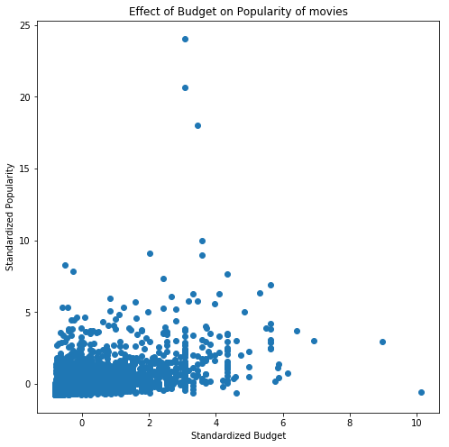

```python
plt.figure(figsize=(8, 8))
plt.ylabel('Standardized Popularity')
plt.xlabel('Standardized Budget')
plt.title('Effect of Budget on Popularity of movies')
plt.scatter(x=budget_std, y=popularity_std);
```

Now let's check whether the runtime has an influence over popularity of a movie.

First let's check in which range of runtime does most number of movies exist. For that let's plot a relationship between the runtime and id. And for that let us create another dataset which stores only those data where the runtime is not equal to 0.

```python
#dataset to store data having runtime values not equal to 0
df_runtime = df.query('runtime != 0')
df_runtime.info()
```

```
<class 'pandas.core.frame.DataFrame'>
Int64Index: 10703 entries, 0 to 10730
Data columns (total 11 columns):
id                10703 non-null int64
popularity        10703 non-null float64
budget            10703 non-null int64
revenue           10703 non-null int64
original_title    10703 non-null object
cast              10703 non-null object
director          10703 non-null object
runtime           10703 non-null int64
genres            10703 non-null object
vote_average      10703 non-null float64
release_year      10703 non-null int64
dtypes: float64(2), int64(5), object(4)
memory usage: 1003.4+ KB
```

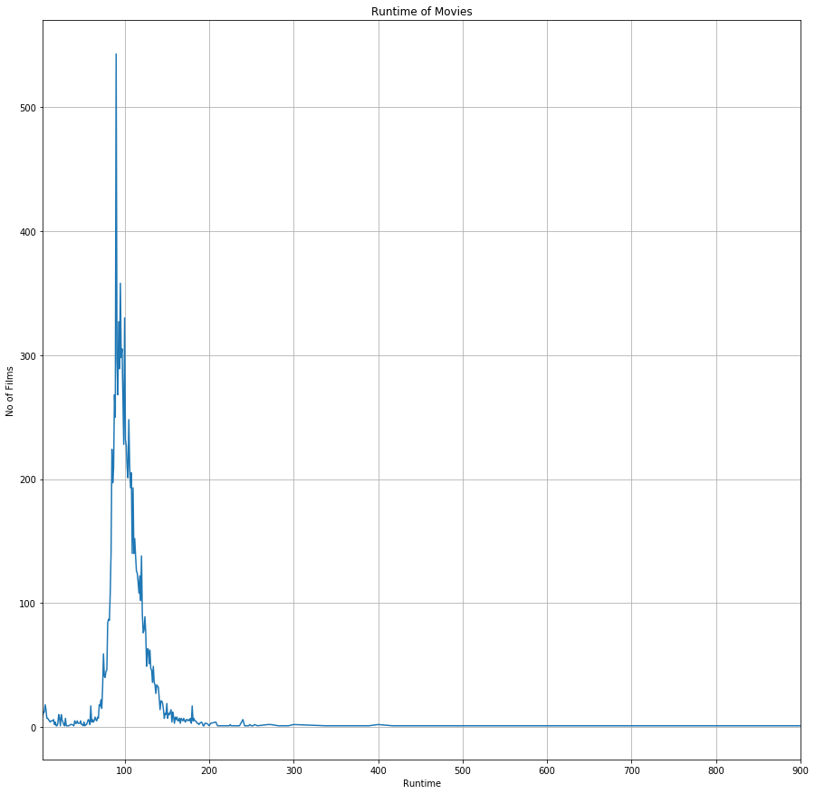

```python
df_duration = df_runtime.groupby('runtime')['id'].count()
a = df_duration.plot(figsize=(15,15), grid=True);
plt.title('Runtime of Movies')
a.set_xlabel('Runtime');
a.set_ylabel('No of Films');
```

```python
a = df_runtime.query('runtime >= 99 and runtime <= 100')
a.shape[0]
```

```
558
```

```python
#to create a runtime array for analysis.
runtime = pd.Series(np.array(df_runtime['runtime']), index = df_runtime['id'])
runtime.head()
```

```
id
135397    124
76341     120
262500    119
140607    136
168259    137
dtype: int64
```

```python
#to create an array for popularity
popularity = pd.Series(np.array(df_runtime['popularity']), index = df_runtime['id'])
popularity.head()
```

```
id
135397    32.985763
76341     28.419936
262500    13.112507
140607    11.173104
168259     9.335014
dtype: float64
```

Now we standardize the values using the standardize function which we had already defined earlier.

```python
runtime_std = standardize(runtime)
runtime_std.head()
```

```
id
135397    0.706934
76341     0.573946
262500    0.540699
140607    1.105898
168259    1.139145
dtype: float64
```

```python
popularity_std = standardize(popularity)
popularity_std.head()
```

```
id
135397    32.150601
76341     27.610383
262500    12.388810
140607    10.460285
168259     8.632504
dtype: float64
```

Now we can calculate the co-relation co-efficient value to know how the runtime and popularity values are related.

```python
# co relation coefficient(Pearson's value)
(popularity_std * runtime_std).mean()
```

```
0.13633865543057386
```

Now we can represent this distribution using a scatter plot.

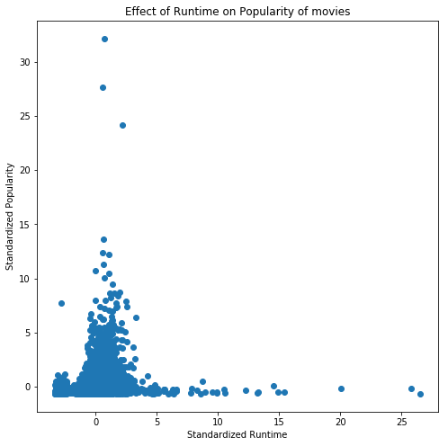

```python
plt.figure(figsize=(8, 8))
plt.xlabel('Standardized Runtime')
plt.ylabel('Standardized Popularity')
plt.title('Effect of Runtime on Popularity of movies')
plt.scatter(x=runtime_std, y=popularity_std);
```

We can also check whether there is a relation between the popularity and revenue of movies.

```python
df.info()
```

```
<class 'pandas.core.frame.DataFrame'>
RangeIndex: 10731 entries, 0 to 10730
Data columns (total 11 columns):
id                10731 non-null int64
popularity        10731 non-null float64
budget            10731 non-null int64
revenue           10731 non-null int64
original_title    10731 non-null object
cast              10731 non-null object
director          10731 non-null object
runtime           10731 non-null int64
genres            10731 non-null object
vote_average      10731 non-null float64
release_year      10731 non-null int64
dtypes: float64(2), int64(5), object(4)
memory usage: 922.3+ KB
```

For this analysis we select data having revenue not equal to 0.

```python
df_revenue = df.query('revenue != 0')
df_revenue.head()
```

|  | id | popularity | budget | revenue | original_title | cast | director | runtime | genres | vote_average | release_year |
| --- | --- | --- | --- | --- | --- | --- | --- | --- | --- | --- | --- |
| 0 | 135397 | 32.985763 | 150000000 | 1513528810 | Jurassic World | Chris Pratt\|Bryce Dallas Howard\|Irrfan Khan\|Vi... | Colin Trevorrow | 124 | Action\|Adventure\|Science Fiction\|Thriller | 6.5 | 2015 |
| 1 | 76341 | 28.419936 | 150000000 | 378436354 | Mad Max: Fury Road | Tom Hardy\|Charlize Theron\|Hugh Keays-Byrne\|Nic... | George Miller | 120 | Action\|Adventure\|Science Fiction\|Thriller | 7.1 | 2015 |
| 2 | 262500 | 13.112507 | 110000000 | 295238201 | Insurgent | Shailene Woodley\|Theo James\|Kate Winslet\|Ansel... | Robert Schwentke | 119 | Adventure\|Science Fiction\|Thriller | 6.3 | 2015 |
| 3 | 140607 | 11.173104 | 200000000 | 2068178225 | Star Wars: The Force Awakens | Harrison Ford\|Mark Hamill\|Carrie Fisher\|Adam D... | J.J. Abrams | 136 | Action\|Adventure\|Science Fiction\|Fantasy | 7.5 | 2015 |
| 4 | 168259 | 9.335014 | 190000000 | 1506249360 | Furious 7 | Vin Diesel\|Paul Walker\|Jason Statham\|Michelle ... | James Wan | 137 | Action\|Crime\|Thriller | 7.3 | 2015 |

```python
df_revenue.shape
```

```
(4843, 11)
```

Only 4843 records have revenue value not equal to 0. So we try to analyse with this data.

```python
#array for popularity data
popularity = pd.Series(np.array(df_revenue['popularity']), index = df_revenue['id'])
popularity.head()
```

```
id
135397    32.985763
76341     28.419936
262500    13.112507
140607    11.173104
168259     9.335014
dtype: float64
```

```python
#array for revenue data
revenue = pd.Series(np.array(df_revenue['revenue']), index = df_revenue['id'])
revenue.head()
```

```
id
135397    1513528810
76341      378436354
262500     295238201
140607    2068178225
168259    1506249360
dtype: int64
```

Now we standardize these values with the "standardize" function defined before.

```python
popularity_std = standardize(popularity)
popularity_std.head()
```

```
id
135397    23.535395
76341     20.170949
262500     8.891280
140607     7.462182
168259     6.107739
dtype: float64
```

```python
revenue_std = standardize(revenue)
revenue_std.head()
```

```
id
135397     8.783817
76341      1.783029
262500     1.269897
140607    12.204668
168259     8.738920
dtype: float64
```

Since we got the standardized values we can now find the correlation coefficient.

```python
# co relation coefficient(Pearson's value)
(popularity_std * revenue_std).mean()
```

```
0.6291667288944971
```

The Pearson's coefficient value is a positive value which denotes that there is a strong relationship between the popularity of a movie and its revenue, proportionally. Therefore revenue is one of the factors that decides the popularity of the movie.

Now we can represent this distribution using a scatter plot.

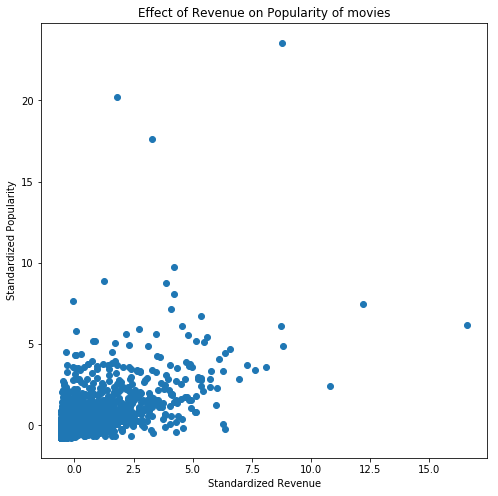

```python
plt.figure(figsize=(8, 8))
plt.xlabel('Standardized Revenue')
plt.ylabel('Standardized Popularity')
plt.title('Effect of Revenue on Popularity of movies')
plt.scatter(x=revenue_std, y=popularity_std);
```

### Research Question 2 - Which genre is the most popular and it's transition through the years.

Here we explore the genres of the films. We analyse the data and come to a conclusion regarding which genre is the most popular through the years. We get the relationship between the number of films under each genre and then get the one with the most number of films released under it. For that we fist read the edited csv file.

```python
df = pd.read_csv('tmdb-movies_edited.csv', encoding = "ISO-8859-1")#utf-8 encoding throws an error. so used ISO-8859-1 encoding
df.head()
```

|  | id | popularity | budget | revenue | original_title | cast | director | runtime | genres | vote_average | release_year |
| --- | --- | --- | --- | --- | --- | --- | --- | --- | --- | --- | --- |
| 0 | 135397 | 32.985763 | 150000000 | 1513528810 | Jurassic World | Chris Pratt\|Bryce Dallas Howard\|Irrfan Khan\|Vi... | Colin Trevorrow | 124 | Action\|Adventure\|Science Fiction\|Thriller | 6.5 | 2015 |
| 1 | 76341 | 28.419936 | 150000000 | 378436354 | Mad Max: Fury Road | Tom Hardy\|Charlize Theron\|Hugh Keays-Byrne\|Nic... | George Miller | 120 | Action\|Adventure\|Science Fiction\|Thriller | 7.1 | 2015 |
| 2 | 262500 | 13.112507 | 110000000 | 295238201 | Insurgent | Shailene Woodley\|Theo James\|Kate Winslet\|Ansel... | Robert Schwentke | 119 | Adventure\|Science Fiction\|Thriller | 6.3 | 2015 |
| 3 | 140607 | 11.173104 | 200000000 | 2068178225 | Star Wars: The Force Awakens | Harrison Ford\|Mark Hamill\|Carrie Fisher\|Adam D... | J.J. Abrams | 136 | Action\|Adventure\|Science Fiction\|Fantasy | 7.5 | 2015 |
| 4 | 168259 | 9.335014 | 190000000 | 1506249360 | Furious 7 | Vin Diesel\|Paul Walker\|Jason Statham\|Michelle ... | James Wan | 137 | Action\|Crime\|Thriller | 7.3 | 2015 |

In the given data the multiple genres are given in a single row seperated by a '|' de limiter. So first we have to change that normal single values for each film i.e a film "A" having genres "action|adventure|mystery" should be changed to "A" - action(col1) "A" - adventure(col2) and "A" - mystery(col3). The below codes does that.

```python
#to split the genres into different columns
a = lambda x: pd.Series([i for i in (x.split('|'))])
df_genre = df['genres'].apply(a)
df_genre.head()
```

|  | 0 | 1 | 2 | 3 | 4 |
| --- | --- | --- | --- | --- | --- |
| 0 | Action | Adventure | Science Fiction | Thriller | NaN |
| 1 | Action | Adventure | Science Fiction | Thriller | NaN |
| 2 | Adventure | Science Fiction | Thriller | NaN | NaN |
| 3 | Action | Adventure | Science Fiction | Fantasy | NaN |
| 4 | Action | Crime | Thriller | NaN | NaN |

```python
#now we rename the columns
df_genre.rename(columns={0:'genre1',1:'genre2',2:'genre3', 3:'genre4', 4:'genre5'},inplace=True)
df_genre = df_genre[['genre1','genre2','genre3', 'genre4', 'genre5']]
df_genre.head()
```

|  | genre1 | genre2 | genre3 | genre4 | genre5 |
| --- | --- | --- | --- | --- | --- |
| 0 | Action | Adventure | Science Fiction | Thriller | NaN |
| 1 | Action | Adventure | Science Fiction | Thriller | NaN |
| 2 | Adventure | Science Fiction | Thriller | NaN | NaN |
| 3 | Action | Adventure | Science Fiction | Fantasy | NaN |
| 4 | Action | Crime | Thriller | NaN | NaN |

Now we insert these columns to the original dataframe df and then drop the existing column genres.

```python
#inserting df_genre columns to df
columns = ['genre1', 'genre2', 'genre3', 'genre4', 'genre5']

for c in columns:
    df[c] = df_genre[c]
```

```python
#drop the existing genres column
df.drop('genres', axis=1, inplace=True)
```

```python
df.info()
```

```
<class 'pandas.core.frame.DataFrame'>
RangeIndex: 10731 entries, 0 to 10730
Data columns (total 15 columns):
id                10731 non-null int64
popularity        10731 non-null float64
budget            10731 non-null int64
revenue           10731 non-null int64
original_title    10731 non-null object
cast              10731 non-null object
director          10731 non-null object
runtime           10731 non-null int64
vote_average      10731 non-null float64
release_year      10731 non-null int64
genre1            10731 non-null object
genre2            8460 non-null object
genre3            5051 non-null object
genre4            1972 non-null object
genre5            539 non-null object
dtypes: float64(2), int64(5), object(8)
memory usage: 1.2+ MB
```

```python
#we write it into a different file for future usage
df.to_csv('tmdb-movies_genres_split.csv', index=False)
```

```python
#read the latest edited csv file
df = pd.read_csv('tmdb-movies_genres_split.csv', encoding = "ISO-8859-1")
```

```python
df.head()
```

|  | id | popularity | budget | revenue | original_title | cast | director | runtime | vote_average | release_year | genre1 | genre2 | genre3 | genre4 | genre5 |
| --- | --- | --- | --- | --- | --- | --- | --- | --- | --- | --- | --- | --- | --- | --- | --- |
| 0 | 135397 | 32.985763 | 150000000 | 1513528810 | Jurassic World | Chris Pratt\|Bryce Dallas Howard\|Irrfan Khan\|Vi... | Colin Trevorrow | 124 | 6.5 | 2015 | Action | Adventure | Science Fiction | Thriller | NaN |
| 1 | 76341 | 28.419936 | 150000000 | 378436354 | Mad Max: Fury Road | Tom Hardy\|Charlize Theron\|Hugh Keays-Byrne\|Nic... | George Miller | 120 | 7.1 | 2015 | Action | Adventure | Science Fiction | Thriller | NaN |
| 2 | 262500 | 13.112507 | 110000000 | 295238201 | Insurgent | Shailene Woodley\|Theo James\|Kate Winslet\|Ansel... | Robert Schwentke | 119 | 6.3 | 2015 | Adventure | Science Fiction | Thriller | NaN | NaN |
| 3 | 140607 | 11.173104 | 200000000 | 2068178225 | Star Wars: The Force Awakens | Harrison Ford\|Mark Hamill\|Carrie Fisher\|Adam D... | J.J. Abrams | 136 | 7.5 | 2015 | Action | Adventure | Science Fiction | Fantasy | NaN |
| 4 | 168259 | 9.335014 | 190000000 | 1506249360 | Furious 7 | Vin Diesel\|Paul Walker\|Jason Statham\|Michelle ... | James Wan | 137 | 7.3 | 2015 | Action | Crime | Thriller | NaN | NaN |

Now we have got the genres in seperate columns for a single movie. For that we have to create sepearte dataframes for each genre column and then concatenate them together into a single file. We also include the release year corresponding to each genre column.

```python
df_genre1 = df[['genre1', 'release_year']]
df_genre1.rename(columns={'genre1': 'genre'}, inplace=True)
df_genre1.count()
```

```
genre           10731
release_year    10731
dtype: int64
```

```python
df_genre2 = df[['genre2', 'release_year']]
df_genre2.rename(columns={'genre2': 'genre'}, inplace=True)
df_genre2.count()
```

```
genre            8460
release_year    10731
dtype: int64
```

```python
df_genre3 = df[['genre3', 'release_year']]
df_genre3.rename(columns={'genre3': 'genre'}, inplace=True)
df_genre3.count()
```

```
genre            5051
release_year    10731
dtype: int64
```

```python
df_genre4 = df[['genre4', 'release_year']]
df_genre4.rename(columns={'genre4': 'genre'}, inplace=True)
df_genre4.count()
```

```
genre            1972
release_year    10731
dtype: int64
```

```python
df_genre5 = df[['genre5', 'release_year']]
df_genre5.rename(columns={'genre5': 'genre'}, inplace=True)
df_genre5.count()
```

```
genre             539
release_year    10731
dtype: int64
```

```python
#to concatenate the different genre dataframes
frames = [df_genre1, df_genre2, df_genre3, df_genre4, df_genre5]
result = pd.concat(frames)
```

```python
result.count()
```

```
genre           26753
release_year    53655
dtype: int64
```

We save the changes to a seperate file for easy access in the future.

```python
result.to_csv('genres_concatenated_list.csv', index=False)
```

```python
df = pd.read_csv('genres_concatenated_list.csv')
```

```python
df.head()
```

|  | genre | release_year |
| --- | --- | --- |
| 0 | Action | 2015 |
| 1 | Action | 2015 |
| 2 | Adventure | 2015 |
| 3 | Action | 2015 |
| 4 | Action | 2015 |

We plot a bar graph to get to know how many of each genre are present and which genre has the highest count.

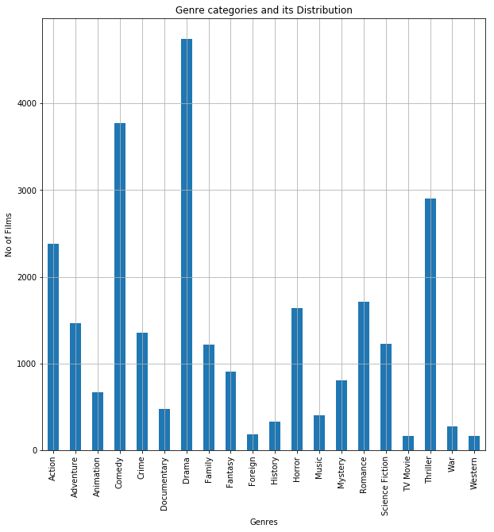

```python
x = df.groupby('genre').count().plot.bar(figsize=(10, 10), legend=False, grid=True);
x.set_title('Genre categories and its Distribution')
x.set_xlabel('Genres')
x.set_ylabel('No of Films');
```

From the above graph we can see that the genre 'Drama' has the highest count followed by Comedy then by Thriller and then by Action after which comes Romance and Horror.

Now we should know how the transition of these genres through the given years were.

For that first we group the genres based on the release years as shown below.

```python
#group genres according to the release years.
df_grouped = df.groupby(['release_year', 'genre'])['genre'].count()
df_grouped.head()
```

```
release_year  genre
1960          Action        8
              Adventure     5
              Comedy        8
              Crime         2
              Drama        13
Name: genre, dtype: int64
```

```python
#we unstack the dataframe to get the years as columns and index as genre and store it in a new data frame a
a = df_grouped.unstack()
a.head()
```

| genre release_year | Action | Adventure | Animation | Comedy | Crime | Documentary | Drama | Family | Fantasy | Foreign | History | Horror | Music | Mystery | Romance | Science Fiction | TV Movie | Thriller | War | Western |
| --- | --- | --- | --- | --- | --- | --- | --- | --- | --- | --- | --- | --- | --- | --- | --- | --- | --- | --- | --- | --- |
| 1960 | 8.0 | 5.0 | NaN | 8.0 | 2.0 | NaN | 13.0 | 3.0 | 2.0 | 1.0 | 5.0 | 7.0 | 1.0 | NaN | 6.0 | 3.0 | NaN | 6.0 | 2.0 | 6.0 |
| 1961 | 7.0 | 6.0 | 1.0 | 10.0 | 2.0 | NaN | 16.0 | 5.0 | 2.0 | 1.0 | 3.0 | 3.0 | 2.0 | 1.0 | 7.0 | 4.0 | NaN | NaN | 2.0 | 3.0 |
| 1962 | 8.0 | 7.0 | NaN | 5.0 | 3.0 | NaN | 21.0 | 2.0 | 1.0 | 1.0 | 4.0 | 5.0 | 1.0 | 4.0 | 5.0 | 2.0 | NaN | 7.0 | 3.0 | 3.0 |
| 1963 | 4.0 | 7.0 | 1.0 | 13.0 | 4.0 | NaN | 13.0 | 3.0 | 2.0 | 2.0 | 4.0 | 9.0 | NaN | 6.0 | 8.0 | 2.0 | NaN | 10.0 | 1.0 | 2.0 |
| 1964 | 5.0 | 5.0 | 2.0 | 16.0 | 10.0 | NaN | 20.0 | 4.0 | 4.0 | 1.0 | 3.0 | 6.0 | 5.0 | 4.0 | 9.0 | 4.0 | NaN | 9.0 | 3.0 | 1.0 |

Now we can plot a line graph with all these values.

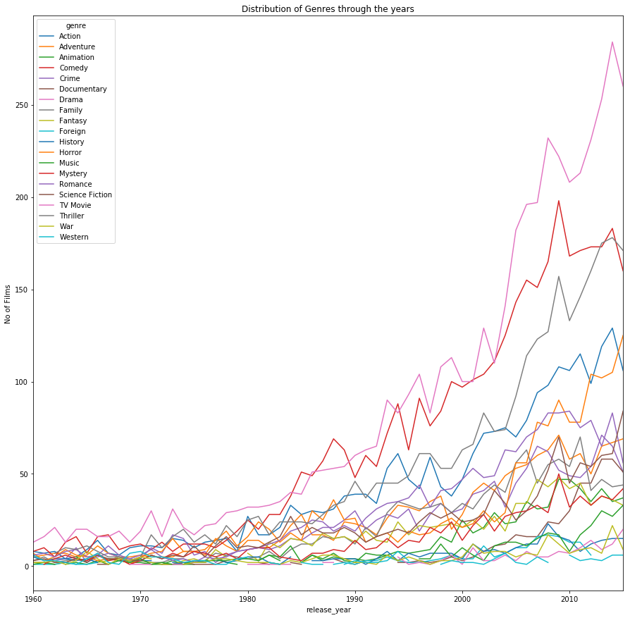

```python
b = a.plot(figsize = (15, 15));
b.set_ylabel('No of Films')
b.set_title('Distribution of Genres through the years');
```

For a better understanding and aesthetical pleasing we can seperate and plot the genres having high counts in one grpah and the others in another graphs. The genres with the highest number of movies can be obtained from the above bar plot.

The top genres are: Drama, Comedy, Thriller, Action, Romance and Horror. Plotting them in a single graph.

```python
a.columns
```

```
Index(['Action', 'Adventure', 'Animation', 'Comedy', 'Crime', 'Documentary',
       'Drama', 'Family', 'Fantasy', 'Foreign', 'History', 'Horror', 'Music',
       'Mystery', 'Romance', 'Science Fiction', 'TV Movie', 'Thriller', 'War',
       'Western'],
      dtype='object', name='genre')
```

```python
#to get the columns of the genres with the highest count of movies and putting them in an array
b = np.r_[0, 3, 6, 11, 14, 17]
b
```

```
array([ 0,  3,  6, 11, 14, 17])
```

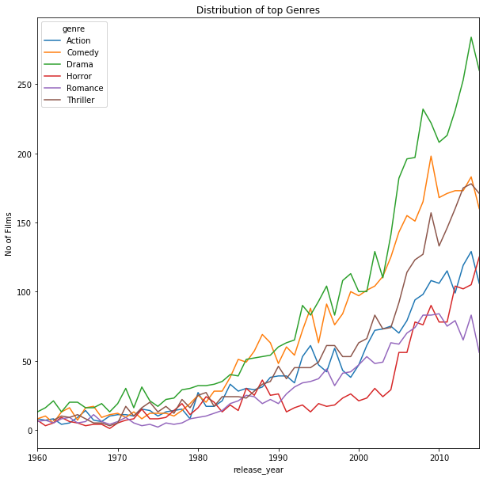

```python
#to plot the top genres in a single graph
c = a.iloc[:, b].plot(figsize=(10, 10));
c.set_ylabel('No of Films')
c.set_title('Distribution of top Genres');
```

Now the next section of genres having the highest number of movies are: Adventure, Crime, Sci-Fi, Family, Fantasy, Mystery and Animation. Now plotting the transition of these genres through the years.

```python
#to get the columns of the genres with the second highest section of counts of movies and putting them in an array
b = np.r_[1, 4, 15, 7, 8, 13, 2]
b
```

```
array([ 1,  4, 15,  7,  8, 13,  2])
```

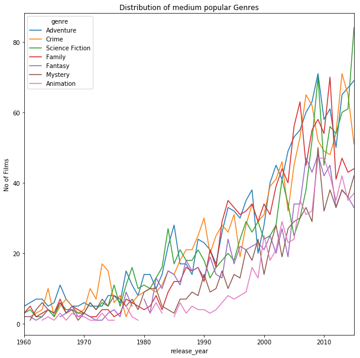

```python
#to plot the second top section of genres in a single graph
c = a.iloc[:, b].plot(figsize=(10, 10))
c.set_ylabel('No of Films')
c.set_title('Distribution of medium popular Genres');
```

And lastly to plot the least popular genres through the ages. They are: Documentary, Music, Histort, War, Foreign, TV Movie, Western.

```python
#to get the columns of the genres with the second highest section of counts of movies and putting them in an array
b = np.r_[5, 12, 10, 18, 9, 16, 19]
b
```

```
array([ 5, 12, 10, 18,  9, 16, 19])
```

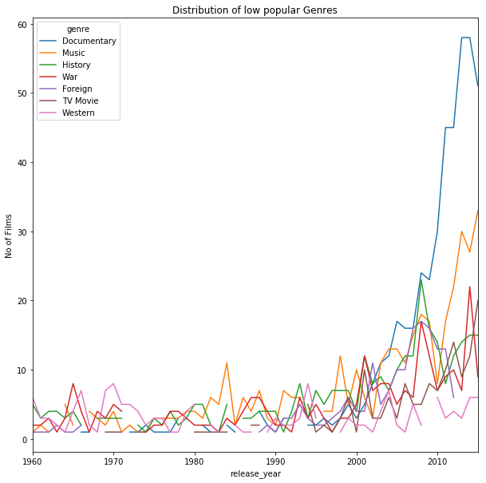

```python
#to plot the second top section of genres in a single graph
c = a.iloc[:, b].plot(figsize=(10, 10))
c.set_ylabel('No of Films')
c.set_title('Distribution of low popular Genres');
```

With this we can see the transition of the popularity or the opposite of al the genres listed through the years. As such we can coclude from the above plots that the number of movies getting released in each genre is increasing as the years go by.